# BMI8050.01, Assignment 1, Spring 2017 - Basics

Piyali Das

Due Date: 19 January 2017

1. Download R from the Comprehensive R Archive Network and install it in on your computer. Use the help function to learn about the commands plot, seq, par, lines, legend, rnorm, hist, paste, image, heatmap, and boxplot. Why did we choose this list of functions for you to learn something about?

These functions are useful to represent a problem in terms of statistics.

2. Plot $\sin(x)$ on the interval $0 \le x \le 3\pi$. Label the axes with something meaningful.

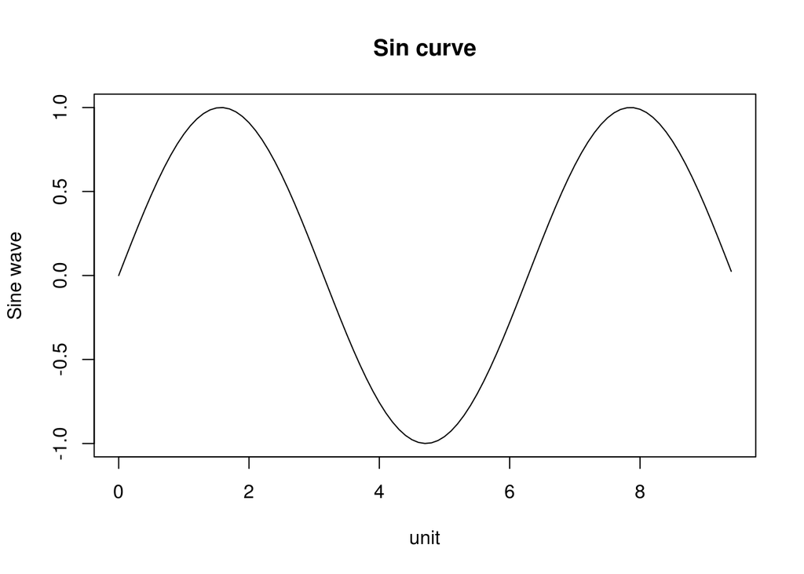

```r
t=seq(0,3*pi, 0.1)
y=sin(t)
plot(t,y,type="l", main = "Sin curve", xlab="unit", ylab="Sine wave")
```

3. Plot both $\sin(x)$ and $\cos(x)$ for $0 \le x \le 3\pi$ on the same axes. Use colors or line styles to distinguish the two curves. Include a figure legend that explains how to tell which curve is which.

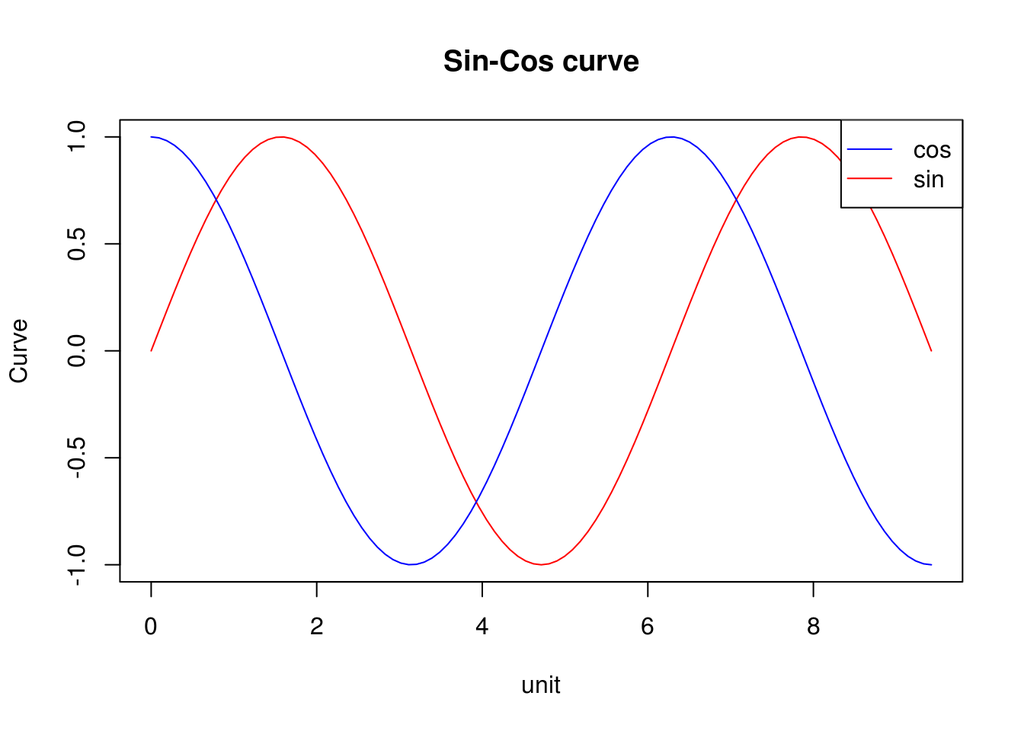

```r
plot(sin, 0, 3*pi, xlab="unit", ylab="Curve", col="red", main = "Sin-Cos curve")
curve(cos, 0, 3*pi, xlab="unit", col="blue", add=TRUE)
legend('topright',c("cos","sin"), lty=c(1,1), col=c("blue","red"), merge = TRUE)
```

4. Generate a random normal vector containing $1000$ elements.
   1. Plot the data.
   2. Plot the data after first sorting it in increasing order.
   3. Plot a histogram of the data.
   4. Plot a histogram of the data with $70$ bars.

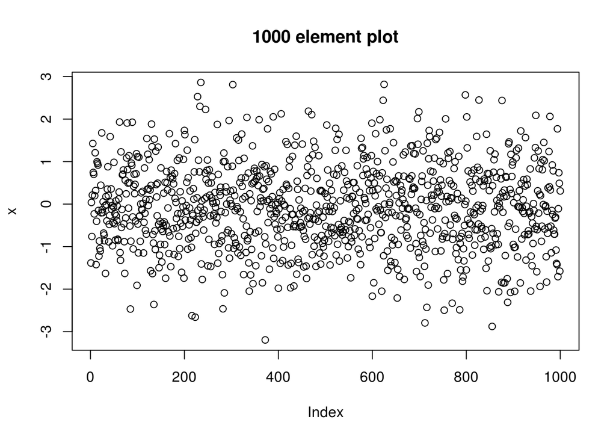

```r
set.seed(124)
x<-rnorm(1000)
plot(x, main = "1000 element plot")
```

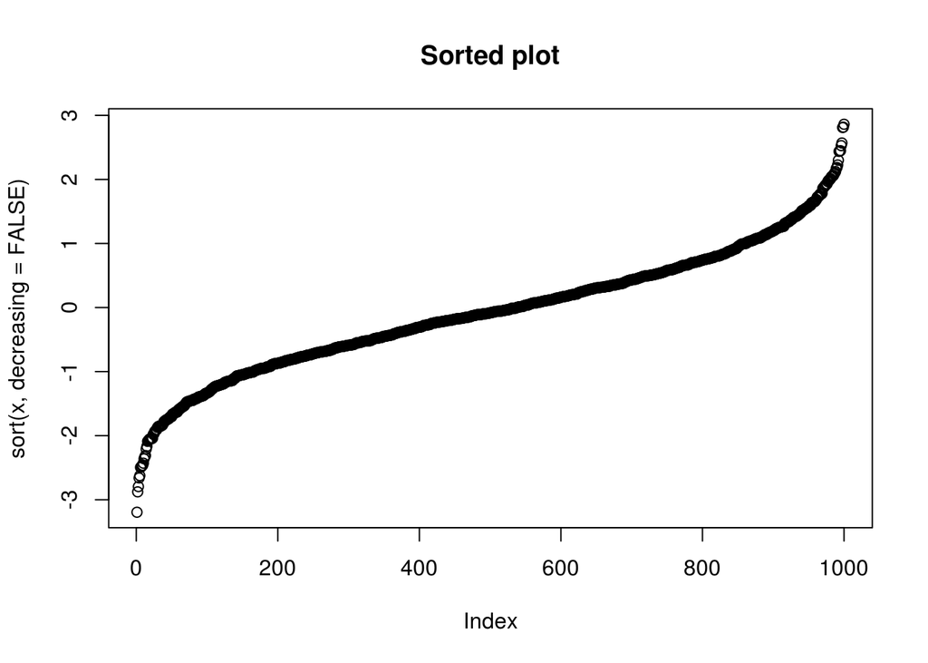

```r
plot(sort(x,decreasing =FALSE), main = "Sorted plot")
```

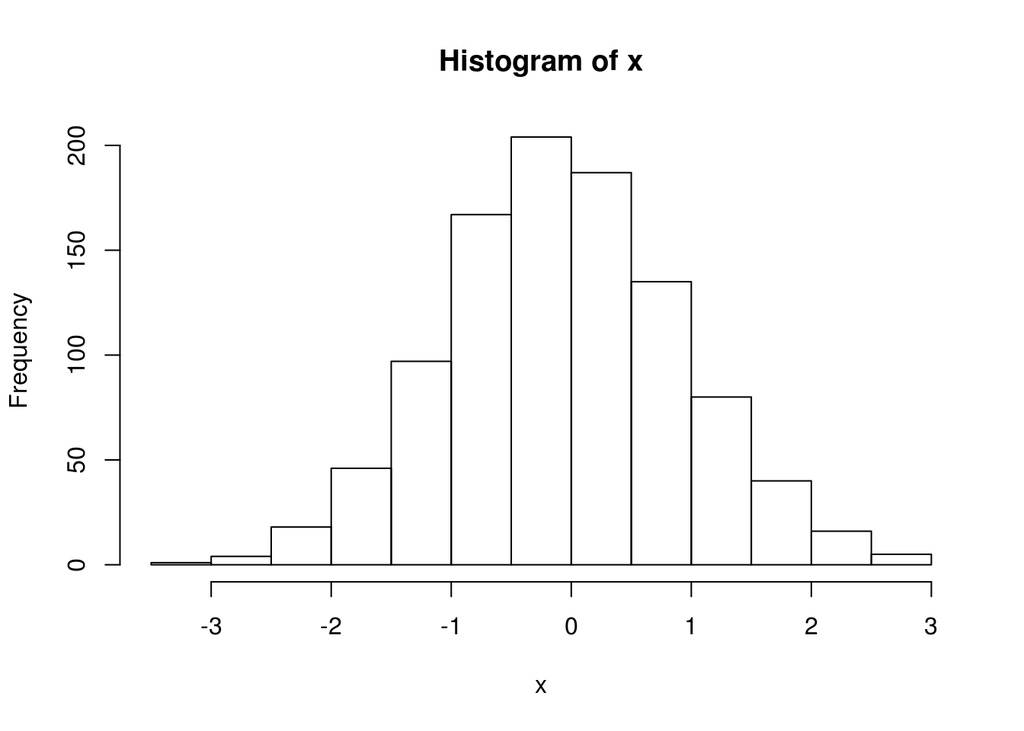

```r
hist(x)
```

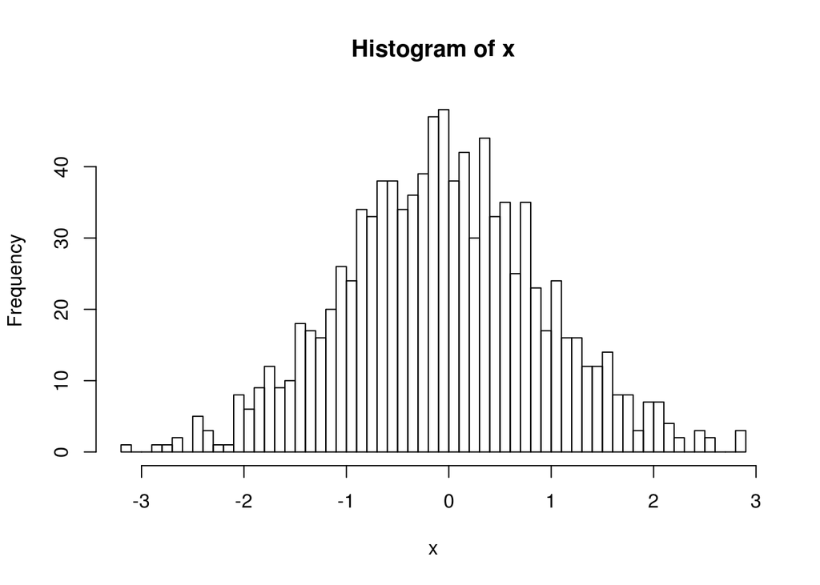

```r
hist(x, breaks=70)
```

5. Generate two random normal vectors $x$ and $y$, each containing $100$ elements.
   1. Compute the correlation coefficient between $x$ and $y$.

```r
set.seed(124)
x<-rnorm(100)
set.seed(1)
y<-rnorm(100)
cor(x,y)
```

```
## [1] -0.03817069
```

```
b. Plot $y$ as a function of $x$, and add the correlation coefficient to the plot (as a legend, a label, or a text string).
```

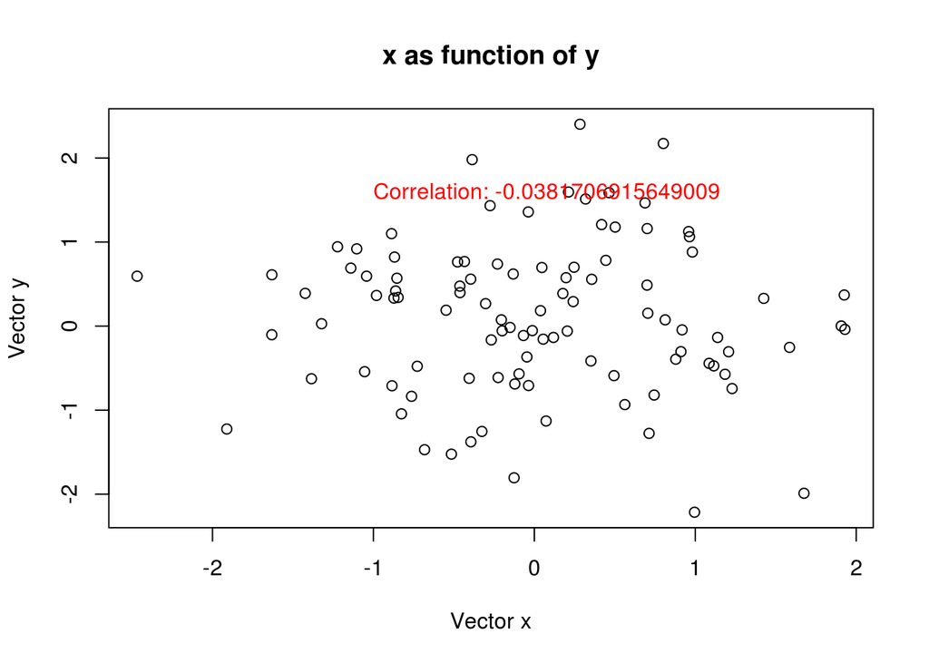

```
c. Perform a $t$-test comparing $x$ and $y$. What are the $t$-statistic and the $p$-value?
```

```r
set.seed(124)
x<-rnorm(100)
set.seed(1)
y<-rnorm(100)
cor <- cor(x,y)
plot(x = x, y = y, xlab = "Vector x", ylab = "Vector y", main = "x as function of y")
text(x = -1, y = 1.6, labels = paste("Correlation:", cor, sep = " "), adj=0, col='red')
```

```r
set.seed(124)
x<-rnorm(100)
set.seed(1)
y<-rnorm(100)
t.test(x, y)
```

```
##
##  Welch Two Sample t-test
##
## data:  x and y
## t = -0.78775, df = 197.95, p-value = 0.4318
## alternative hypothesis: true difference in means is not equal to 0
## 95 percent confidence interval:
##  -0.3477678  0.1492341
## sample estimates:
##   mean of x   mean of y
## 0.009620551 0.108887367
```

t-statistics is: -0.78775 and p-value is: 0.4318

```
d. Let $z=y+1$. Repeat parts (5.a) and (5.c) using $z$ instead of $y$.
```

```r
set.seed(124)
x<-rnorm(100)
set.seed(1)
y<-rnorm(100)
z <- y+1
cor(x,z)
```

```
## [1] -0.03817069
```

```r
t.test(x, z)
```

```
##
##  Welch Two Sample t-test
##
## data:  x and z
## t = -8.7234, df = 197.95, p-value = 1.106e-15
## alternative hypothesis: true difference in means is not equal to 0
## 95 percent confidence interval:
##  -1.3477678 -0.8507659
## sample estimates:
##   mean of x   mean of y
## 0.009620551 1.108887367
```

t-statistics is: -8.7234 and p-value is: 1.106e-15

```
e. Let $z=y+k$ for a constant $k$ of your choice. Repeat parts (5.a) and (5.c) using $z$ instead of $y$. How large should you choose $k$ to ensure that the $p$-value is smaller than 0.05?
```

```r
set.seed(124)
x<-rnorm(100)
set.seed(1)
y<-rnorm(100)
z <- y+0.1498
cor(x,z)
```

```
## [1] -0.03817069
```

```r
t.test(x, z)
```

```
##
##  Welch Two Sample t-test
##
## data:  x and z
## t = -1.9765, df = 197.95, p-value = 0.04949
## alternative hypothesis: true difference in means is not equal to 0
## 95 percent confidence interval:
##  -0.4975677757 -0.0005658554
## sample estimates:
##   mean of x   mean of y
## 0.009620551 0.258687367
```

k should be approximately >0.15 so that the p-value is smaller than 0.05

```
f. Repeat part (5.e) when $x$ and $y$ contain only $25$ elements.
```

```r
set.seed(124)
x<-rnorm(25)
set.seed(1)
y<-rnorm(25)
z <- y+0.397
cor(x,z)
```

```
## [1] -0.2941437
```

```r
mytest <- t.test(x, z)
print(paste0("T statistics is ",round(mytest$statistic,3)," and pvalue is ",round(mytest$p.value, 10)))
```

```
## [1] "T statistics is -2.014 and pvalue is 0.0496945944"
```

In this case k should be approximately >0.4 so that the p-value is smaller than 0.05

6. Generate a random normal matrix with $100$ rows and $50$ columns.
   1. Draw an image of the matrix. Change the axes so they indicate the correct row and column numbers.

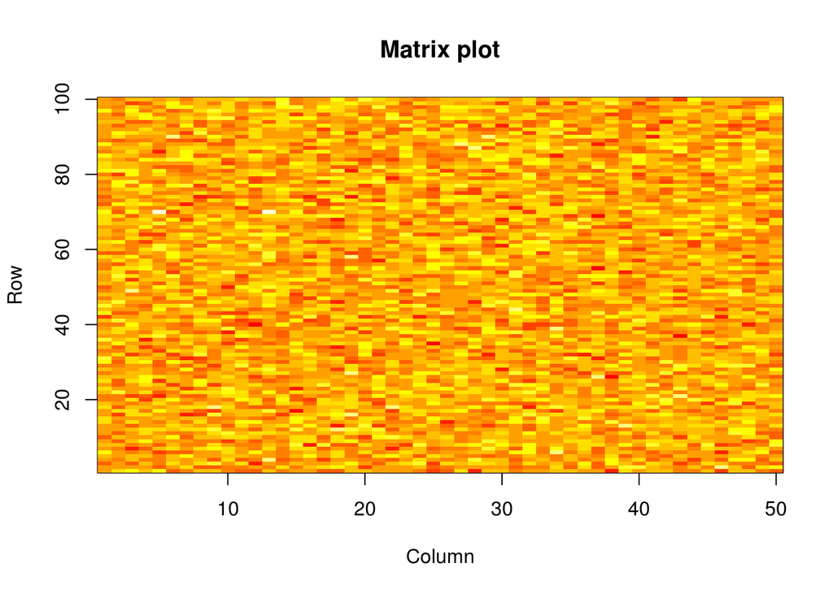

[output not shown]

```r
mat <- matrix( rnorm(100*50), 100, 50)
x <- 1:ncol(mat)
y <- 1:nrow(mat)
image(x, y, t(mat), main = "Matrix plot", xlab = "Column", ylab = "Row")
```

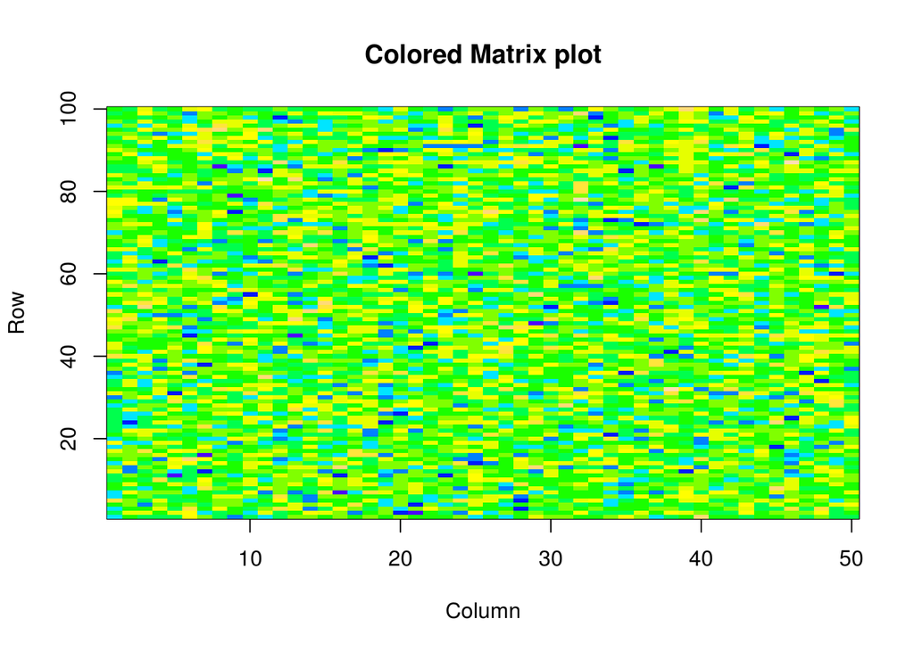

```
c. Draw a heatmap of the matrix.
```

```r
mat <- matrix( rnorm(100*50), 100, 50)
x <- 1:ncol(mat)
y <- 1:nrow(mat)
image(x, y, t(mat), main = "Colored Matrix plot", col = topo.colors(12), xlab = "Column", ylab = "Row")
```

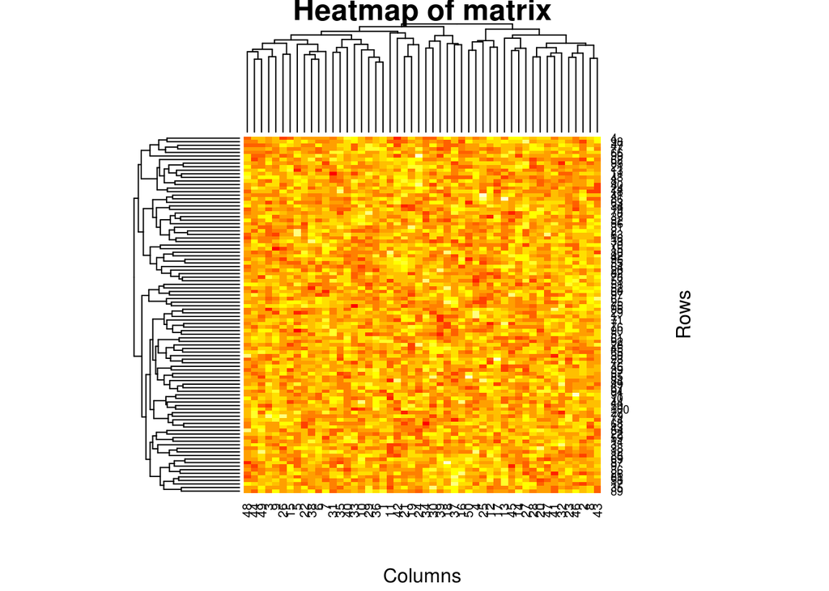

```
d. Convert the matrix into a data.frame, and draw a boxplot of the data.frame.
```

```r
mat <- matrix( rnorm(100*50), 100, 50)
heatmap(mat, xlab = "Columns", ylab = "Rows", main = "Heatmap of matrix")
```

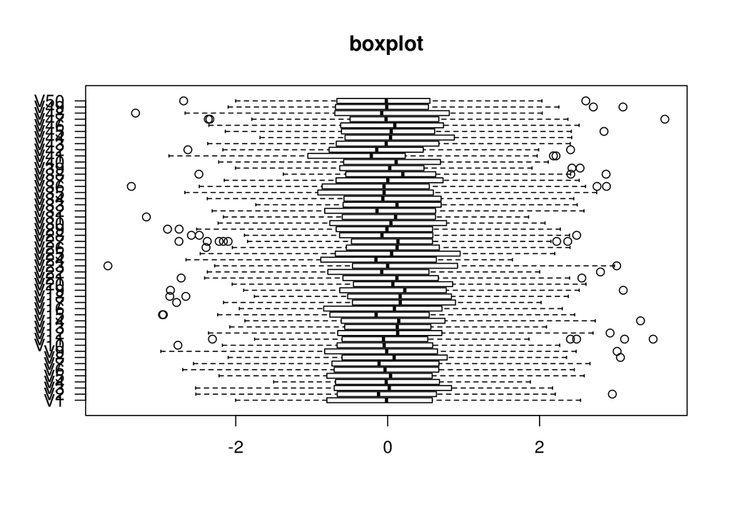

```r
mat <- matrix( rnorm(100*50), 100, 50)
df <- as.data.frame(mat)
par(las = 1) # all axis labels horizontal
boxplot(df, main = "boxplot", horizontal = TRUE)
```

7. Read the R help documentation on “library”, which explains how to use the extra tools available in R libraries. Load the lattice package and work through the examples in the help page for wireframe and cloud.

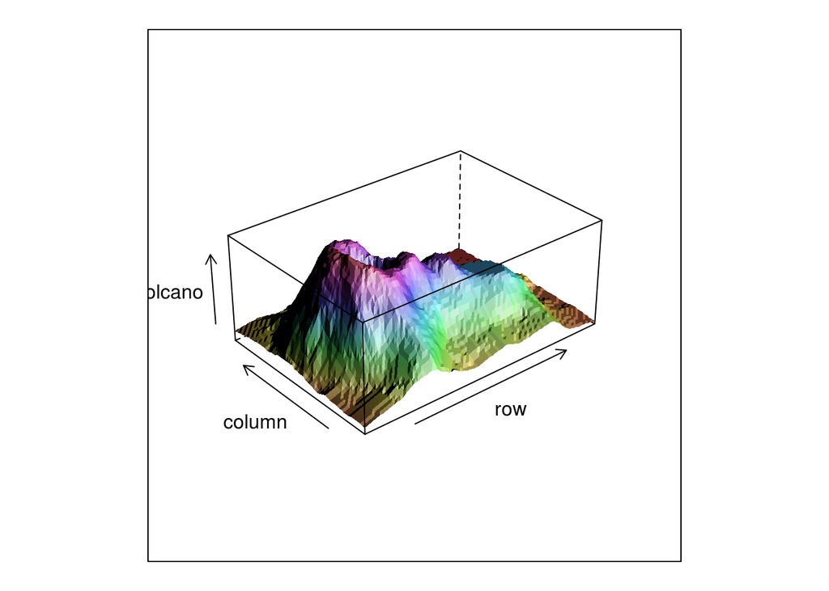

```r
library(lattice)
wireframe(volcano, shade = TRUE, aspect = c(61/87, 0.4), light.source = c(10,0,10))
```

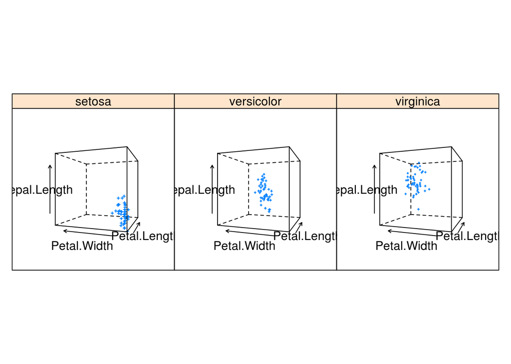

```r
cloud(Sepal.Length ~ Petal.Length * Petal.Width | Species, data = iris,
      screen = list(x = -90, y = 70), distance = .4, zoom = .6)
```

8. Read the R help documentation on “sample”. FInd a way to use “sample” to assign 15 students into 4 groups, of roughly equal size, so each group can work together on a class project.

```r
x <- 1:15

for (i in 1:3){
 print(s <- sample(x, 4))
 x <- x [! x %in% s]
}
```

```
## [1] 10 12  7  9
## [1]  2 15  4  6
## [1] 11  1  5 14
```

```r
print(x)
```

```
## [1]  3  8 13
```

```r
students <- LETTERS[1:15]
set.seed(538734)
groupass <- sample(4,15,replace = TRUE)
groupass
```

```
##  [1] 1 1 3 2 2 2 3 1 1 1 2 4 3 4 3
```

```r
#names(groupass)
names(groupass) <- students
table(groupass)
```

```
## groupass
## 1 2 3 4
## 5 4 4 2
```

```r
sort(groupass)
```

```
## A B H I J D E F K C G M O L N
## 1 1 1 1 1 2 2 2 2 3 3 3 3 4 4
```

```r
#not ideal solution since dosent assin equally
```

```r
students <- LETTERS[1:15]
set.seed(538734)
groups <- rep(0,length(students))
names(groups) <- students
for(i in 1:4)
  groups[sample(15,4)] <- i

table(groups)
```

```
## groups
## 0 2 3 4
## 7 2 2 4
```

```r
# dosent work either due to sampling dosent assign some students
```

```r
students <- LETTERS[1:15]
#set.seed(538734)
groups <- rep(4,length(students))
names(groups) <- students
for(i in 1:3)
  groups[sample(which(groups == 4),3)] <- i
table(groups)
```

```
## groups
## 1 2 3 4
## 3 3 3 6
```

```r
groups
```

```
## A B C D E F G H I J K L M N O
## 1 3 4 4 3 4 3 2 2 1 4 4 2 4 1
```